# Logistic Regression Assignment

John Chandler

## Logistic Regression

Logistic regression allows us to apply the power of regression to cases where our outcome variable is binary (0/1). The fitting process and coefficient interpretation are quite a bit different from linear regression. The technique is powerful and pretty ubiquitous in business, where there are many problems with binary outcomes (e.g., purchasing, re-purchasing, customer attrition, etc.)

## Instructions

Follow along in this document. There are places where I’ve added comments encouraging you to do analyses, make plots, etc. In the modeling section I’ve asked you to build a logistic regression model and in the interpretation section I’ve asked you to interpret it. Do so, then knit your model and commit both your knitted HTML and your RMD.

## Data

The data for this project comes from a local company, TOMIS, who manages bookings, websites, and marketing for a variety of tour operators. They’ve graciously allowed us to use a sample of data on customer booking habits. The data is pretty large (~52 MB) and can be downloaded from Moodle. Once you’ve downloaded it, extract it from its zip file into this folder.

```r
input.data.file <- "trip_scoring_data.txt"

d <- read_tsv(input.data.file)
```

The data set has the following columns:

1. `id`: a unique identifier for the customer.
2. `total_spent`: the amount of money the customer has spent with the tour operator.
3. `days_since_last`: the number of days since the last time the customer booked with this operator.
4. `bookings_in_last_13_months`: the number of bookings in the preceding 13 months.
5. `bookings_in_13_to_26_months`: the number of bookings 13 to 26 months ago.
6. `bookings_more_than_26_months`: the number of bookings more than 26 months ago.
7. `mean_dist_to_client_location`: the mean distance from the customer to the tour operator. This is missing for about 35% of rows.
8. `mean_leading_days`: the mean number of days that the customer books their experiences.
9. `mean_rebook_days`: if the customer rebooks, the mean number of days between those rebookings.
10. `booking_dt`: the calendar date and time of the booking.
11. `experience_dt`: the calendar date and time of the experience, which is what the tours or trips are called.
12. `client`: There are 14 clients in the data set. These are the tour operators.
13. `client_location`: Some clients have multiple locations. This field allows us to differentiate between them.
14. `guests`: The number of people on the experience.
15. `domain`: the web domain of the customer’s email.
16. `rebooked`: our response variable. Zero or one depending on whether or not the customer rebooks. There are 12.4% of rows that have rebookings.

## Data Exploration

Let’s take a look at rebooking rates by client:

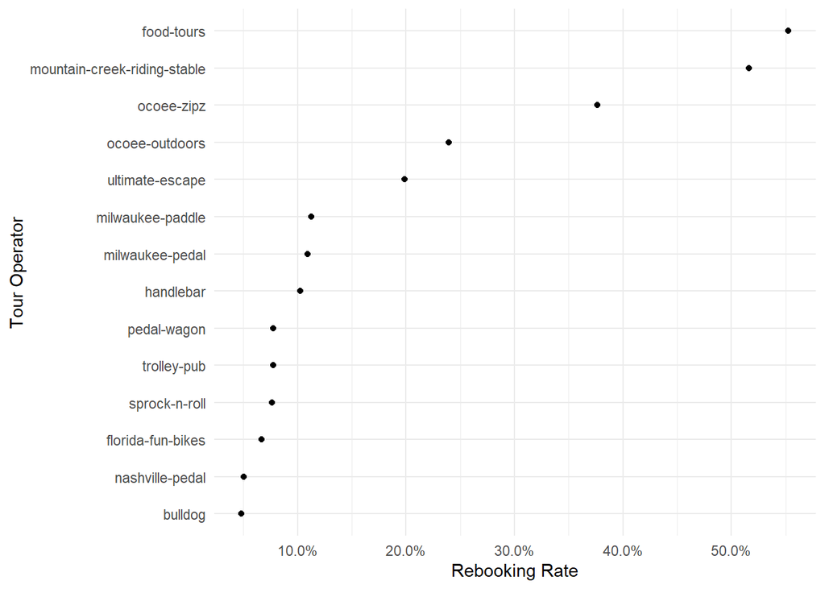

```r
d %>%
  group_by(client) %>%
  summarize(mean_rebook = mean(rebooked)) %>%
  mutate(client = fct_reorder(client,mean_rebook)) %>%
  ggplot(aes(x=mean_rebook,y=client)) +
  geom_point() +
  theme_minimal() +
  labs(x="Rebooking Rate",
       y="Tour Operator") +
  scale_x_continuous(label=percent)
```

As we can see, there’s quite a bit of variability in rebooking rates across clients. Therefore, client is likely to be a useful explanatory variable in our model.

## Model

```r
d <- d %>%
  mutate(client_fct = fct_reorder(client,rebooked,mean))

glm.1 <- glm(rebooked ~ client_fct +
                    total_spent,
                  data=d %>% slice_sample(prop=0.5),
                  family="binomial",
                  subset=total_spent < 20000)

rb.fit <- tidy(glm.1) %>%
  mutate(exp_estimate = exp(estimate),
         lb = exp(estimate - 2*std.error),
         ub = exp(estimate + 2*std.error)) %>%
  mutate(pretty_term = if_else(grepl("client",term),
                               gsub("client_fct","",term),
                               term))
```

## Interpretation

```r
rb.fit %>%
         filter(grepl("client",term)) %>%
         mutate(pretty_term = fct_reorder(pretty_term,exp_estimate)) %>%
  arrange(exp_estimate)
```

```
## # A tibble: 13 x 9
##    term  estimate std.error statistic   p.value exp_estimate     lb    ub
##    <chr>    <dbl>     <dbl>     <dbl>     <dbl>        <dbl>  <dbl> <dbl>
##  1 clie~  -0.0516    0.0439    -1.17  2.40e-  1        0.950  0.870  1.04
##  2 clie~   0.161     0.300      0.537 5.91e-  1        1.17   0.645  2.14
##  3 clie~   0.363     0.114      3.18  1.48e-  3        1.44   1.14   1.81
##  4 clie~   0.383     0.0591     6.48  9.05e- 11        1.47   1.30   1.65
##  5 clie~   0.397     0.0511     7.78  7.19e- 15        1.49   1.34   1.65
##  6 clie~   0.412     0.0495     8.31  9.60e- 17        1.51   1.37   1.67
##  7 clie~   0.583     0.0499    11.7   1.45e- 31        1.79   1.62   1.98
##  8 clie~   0.641     0.0917     6.98  2.86e- 12        1.90   1.58   2.28
##  9 clie~   1.41      0.0783    18.0   2.93e- 72        4.08   3.49   4.77
## 10 clie~   1.54      0.0426    36.2   1.28e-287        4.68   4.30   5.09
## 11 clie~   1.68      0.0728    23.1   5.88e-118        5.37   4.64   6.21
## 12 clie~   2.52      0.0842    29.9   1.78e-196       12.4   10.5   14.7
## 13 clie~   2.98      0.0413    72.0   0.              19.6   18.0   21.3
## # ... with 1 more variable: pretty_term <fct>
```

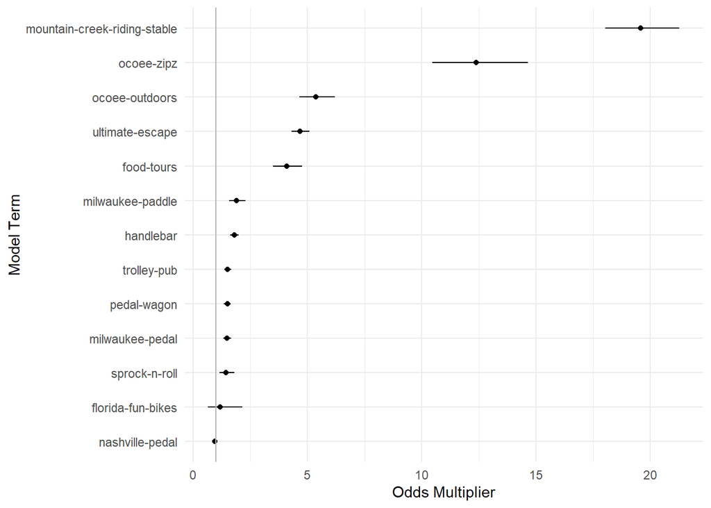

```r
ggplot(rb.fit %>%
         filter(grepl("client",term)) %>%
         mutate(pretty_term = fct_reorder(pretty_term,exp_estimate)),
       aes(x=exp_estimate,y=pretty_term)) +
  geom_point() +
  geom_errorbarh(aes(xmin=lb,xmax=ub,y=pretty_term),
                 height=0) +
  theme_minimal() +
  labs(x="Odds Multiplier",
       y="Model Term") +
  geom_vline(xintercept=1,col="gray70")
```

## Accuracy

```r
  holdout.d <- d %>%
    slice_sample(prop=0.1) %>%
    select(id,rebooked)

  glm.test <- update(glm.1,subset=!(id %in% holdout.d$id))

  holdout.d <- holdout.d %>%
    mutate(predicted_val = predict(glm.1,
                                   newdata=d %>%
                                     filter(id %in% holdout.d$id)))
  holdout.d <- holdout.d %>%
    mutate(est_rebooked = as.numeric(predicted_val >= 0.5))

  confusion.mat <- table(holdout.d$rebooked,holdout.d$est_rebooked)

  rownames(confusion.mat) <- c("Didn't Rebook","Did Rebook")
  colnames(confusion.mat) <- c("Pred No Rebook","Pred Rebook")

  knitr::kable(confusion.mat)
```

|  | Pred No Rebook | Pred Rebook |
| --- | --- | --- |
| Didn’t Rebook | 17689 | 227 |
| Did Rebook | 2516 | 38 |